# Data Cleaning

Author

Timo Roettger

Published

June 6, 2026

# Data cleaning

In the following, we will explore catch trials, control trials, reaction times and dynamics related to how often and how people moved the slider to clean the data. We will suggest and implement exclusion criteria.

## Attention checks

There were 4 attention checks in which participants were asked to indicate a particular slide position. We flag all responses that are more than one slider position of the target slider position.

```
# A tibble: 4 × 2
# Groups:   catch_amount [4]
  catch_amount     n
         <dbl> <int>
1            0     3
2            2     3
3            3    10
4            4    24
```

There were 6 participants (15 %) who failed to correctly respond to 3 out of 4 catch trials.

These participants are excluded.

## Control trials

There were 14 trials per participant that presented a flat tone (`delta_t & delta_f = 0`) for which the correct response was 0 Hz.

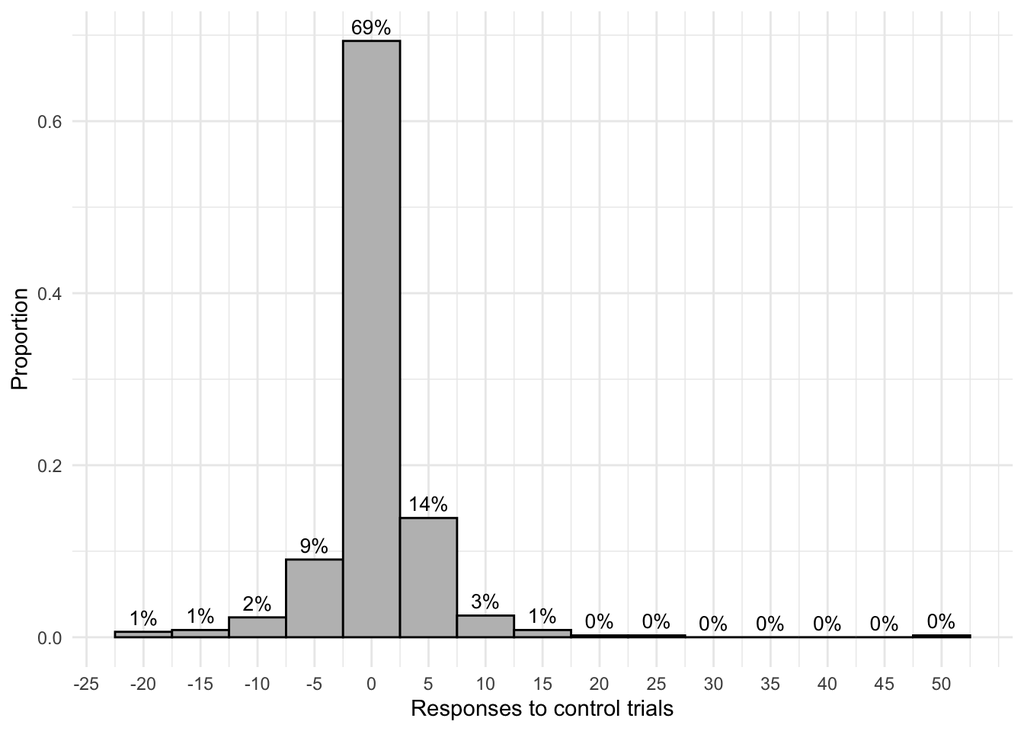

Distribution of control trials on flat tones.

Most responses to the control trials are correct followed by the adjacent pitch responses (-5 Hz and 5 Hz) with a slight bias towards higher values. We expect that some people might have slight response biases (hearing a flat tone as slightly rising or falling) but consistently judge the flat pitch with some level of symmetric-ish noise. Ideally we identify participants that do not show such a pattern, indicating either inattentiveness or other non-desirable response behavior.

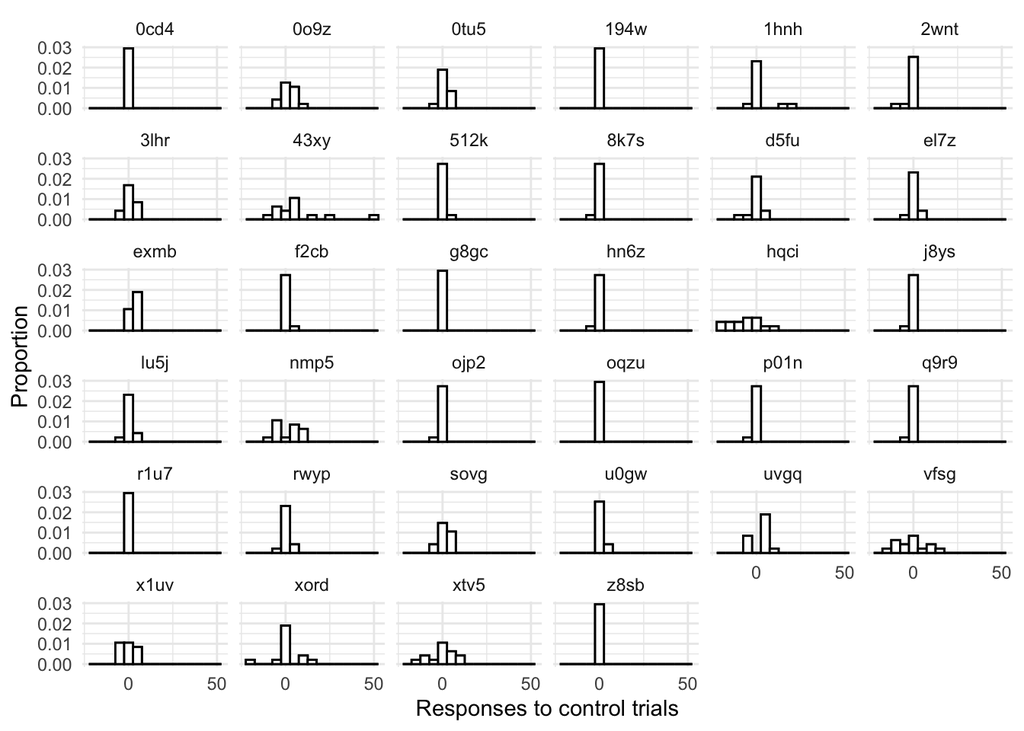

Distribution of control trials on flat tones per participant.

We can see that most distributions look unimodal-ish. Some participants have wider distributions than others, so we need to take this into account. Let’s calculate the mean and SD of control responses per participant and store the information for later.

```
# A tibble: 34 × 3
   participantID control_response_bias control_response_noise
   <chr>                         <dbl>                  <dbl>
 1 43xy                          6.43                   15.4
 2 hqci                         -6.43                    9.08
 3 vfsg                         -1.07                    8.81
 4 xord                          0.714                   8.05
 5 xtv5                         -0.357                   7.46
 6 nmp5                          1.07                    6.84
 7 1hnh                          2.14                    6.71
 8 uvgq                          2.5                     5.10
 9 0o9z                          1.79                    4.21
10 x1uv                         -0.357                   4.14
# ℹ 24 more rows
```

Response biases vary quite a bit between participants but are generally very small. Consistency (measured as standard deviation) of their control responses also varies a lot. Having a strict exclusion criterion on a by-trial bias, could be too strict. So we define extreme responses to the control as a abs(20) response, which corresponds to four slider positions above/below the correct response.

We will remove participants who give extreme control responses in more than 30% of control trials corresponding to 4 out of 14 control trials.

There were 0 participants who responded more than 4 times to the control task with extreme values (`abs(20)` Hz).

## Move dynamics

Participants were able to move the scale position as often as they wished. Each move was recorded as a string in `response_list`.

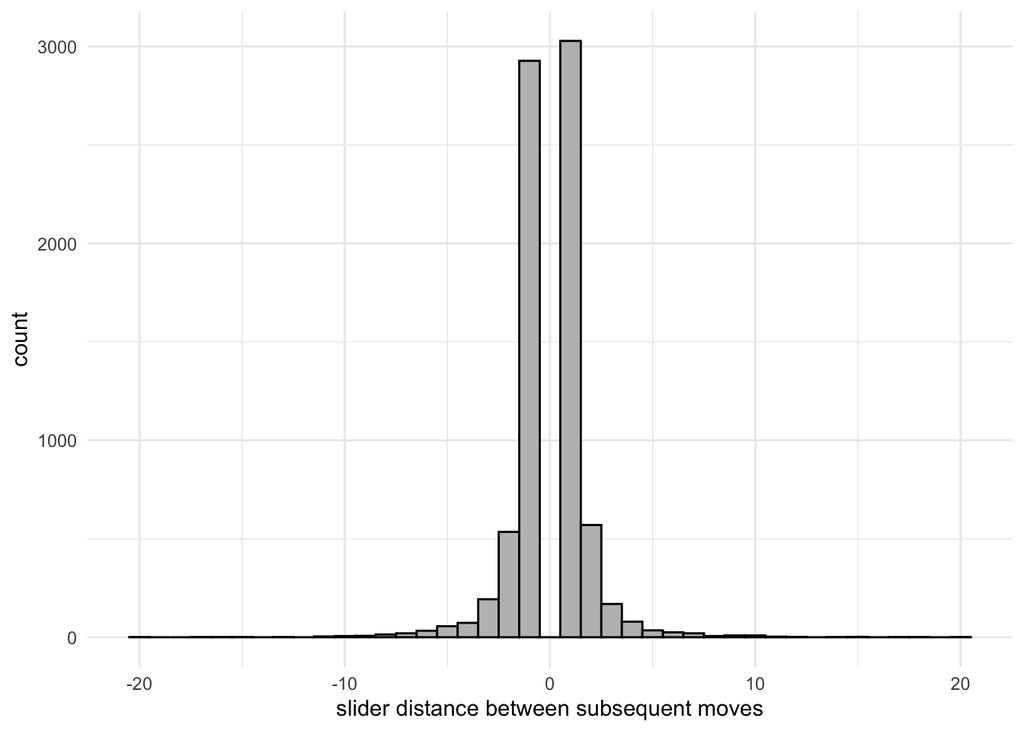

Distribution of slider distance between subsequent moves.

As expected, moves were mostly one step up or down to adjacent slider positions, resulting in a symmetric distribution around zero. High values indicate a strong jump and can be expected to occur at the beginning of a trial but not at the end. Let’s look at the final move which ideally should not contains big jumps.

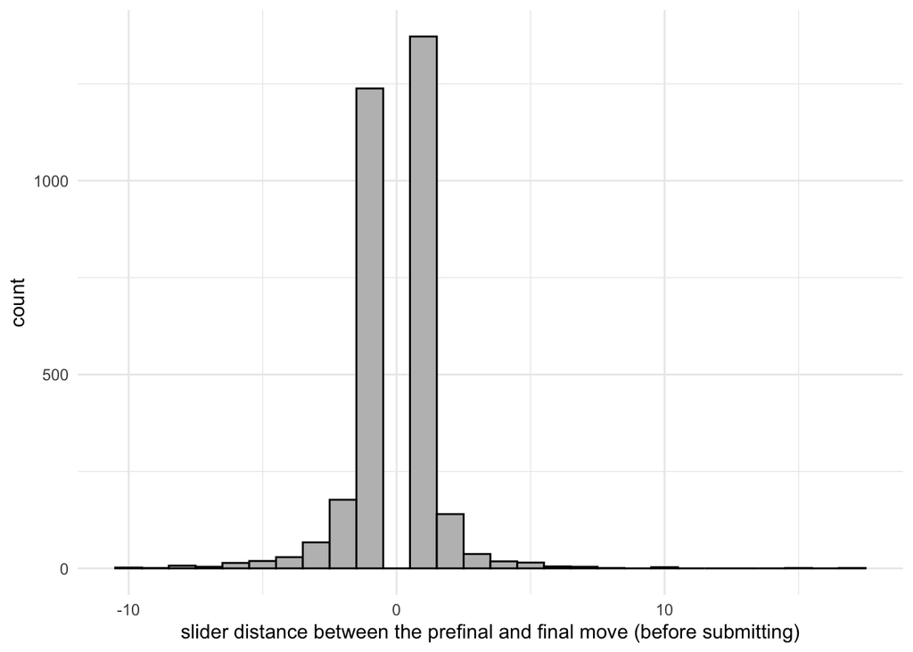

Distribution of slider distanct only for the last move before submitting.

There are indeed some larger values, up to jumps of 10 and higher. I think we should exclude moves that are beyond a certain threshold. Having said that, it could be that someone explores negative and positive scale positions to get a better feel for them and then jumps to an earlier explored part of the scale, even if that means a larger jump? However, a jump of 8 slider positions corresponds to 40 Hz, corresponding to a jump from a flat tone to our most extreme f0 perturbation. We exclude all trials with a final jump as large, or larger than 40 Hz.

```
[1] 4284
```

## Reaction time and amount of moves

Participants were able to make multiple moves before arriving at their final choice. How much did they move?

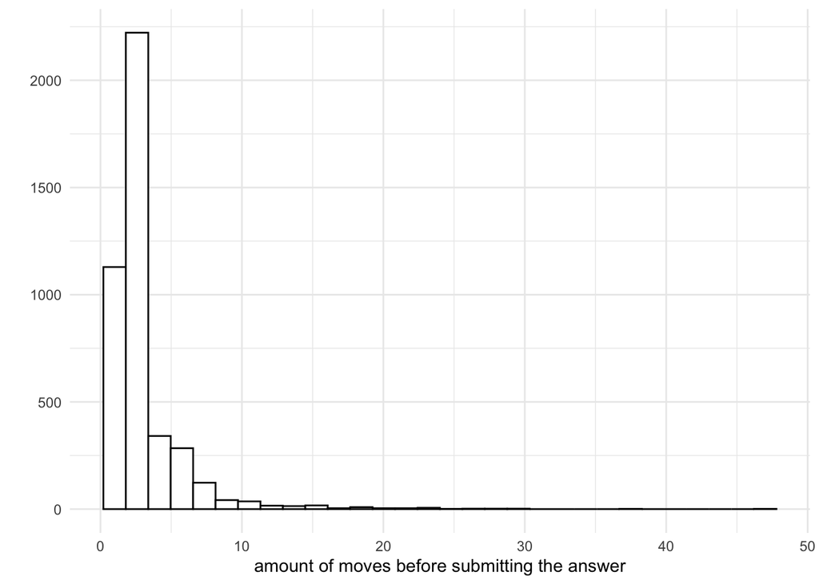

Distribution of amount of moves overall

Mostly 1-2 moves with a heavy right tale. Presumably this changed throughout the experiment.

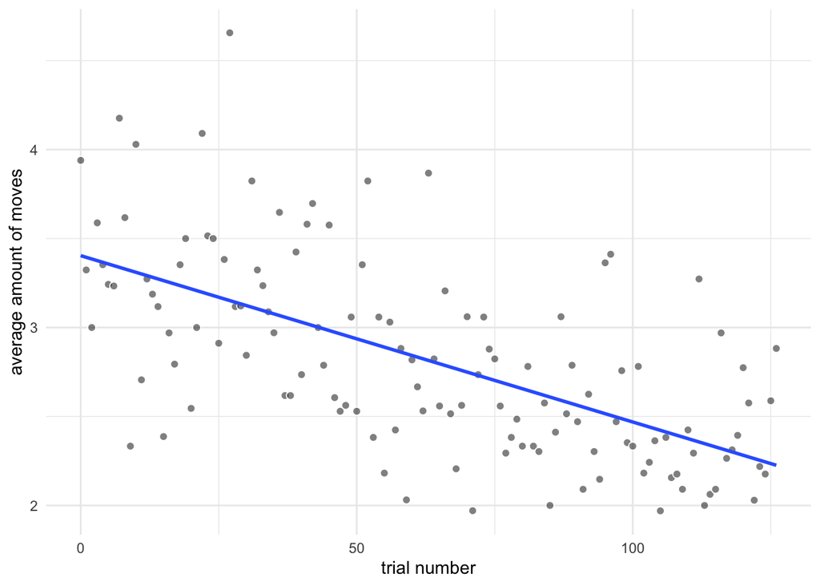

Distribution of amount of moves across trials

The amount of moves decreases over the experiment as expected. Given that, we expect reaction times to substantially decrease over the course of the experiment. When excluding trials based on reaction times, we will take this into consideration.

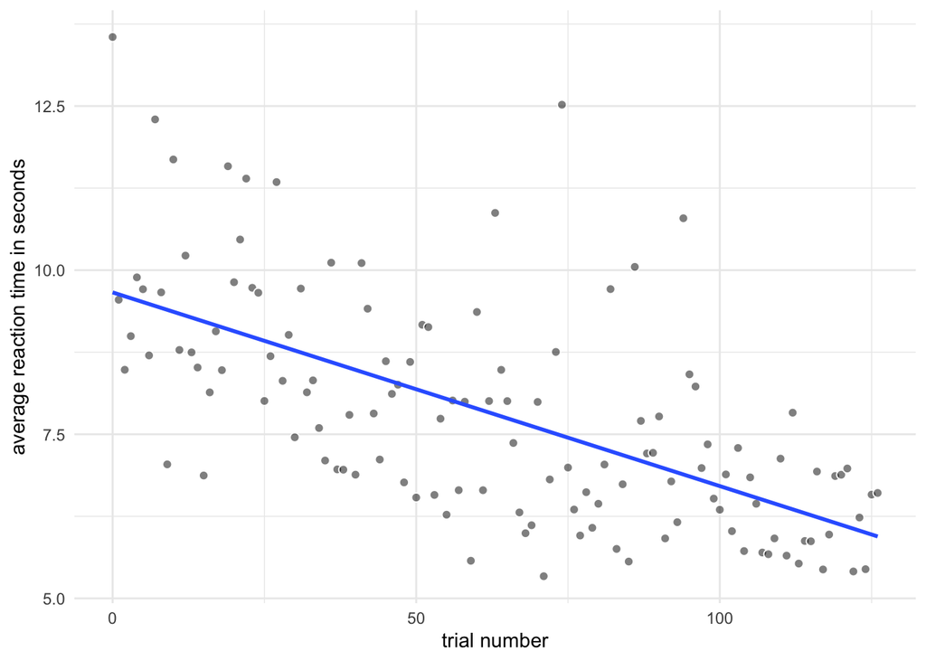

Distribution of RT across trials

To account for outliers due to attentional lapses and distractions, we further removed trials that elicited reaction times that were more than 4 SDs from the median (1.3%) for each participant for each quarter of the experiment (trials binned into 4 equal bins), respectively.

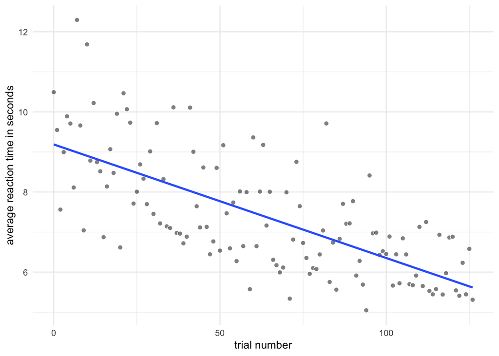

Distribution of RT across trials after data trimming

How much data did we overall lose?

All in all, we excluded 16.6% of data.